# Project_Full_Code_Notebook_EasyVisa

## AdaBoost

```
            Accuracy    Recall  Precision        F1
Dataset
Train       0.740123  0.881207   0.765266  0.819154
Validation  0.735871  0.885983   0.758872  0.817516
Test        0.729396  0.876322   0.756914  0.812253
```

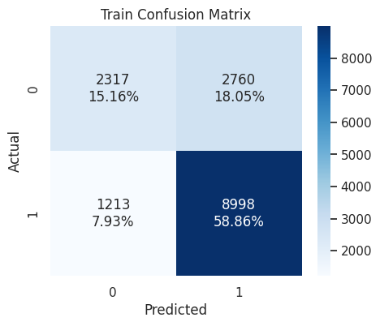

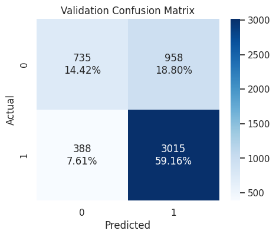

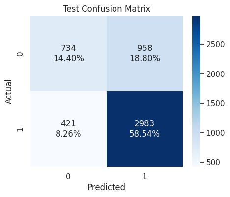

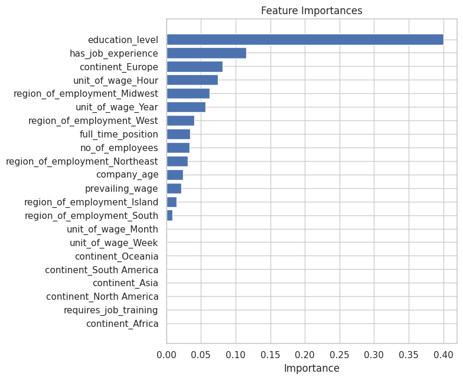

```python
# AdaBoost
ada_model = AdaBoostClassifier(random_state=1)
ada_model.fit(X_train, y_train)

# Evaluate performance
evaluate_model(ada_model)
```

## Bagging Classifier

```
            Accuracy    Recall  Precision        F1
Dataset
Train       0.984890  0.986975   0.990369  0.988669
Validation  0.703885  0.783426   0.775451  0.779418
Test        0.690934  0.774971   0.765303  0.770107
```

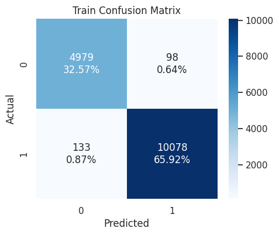

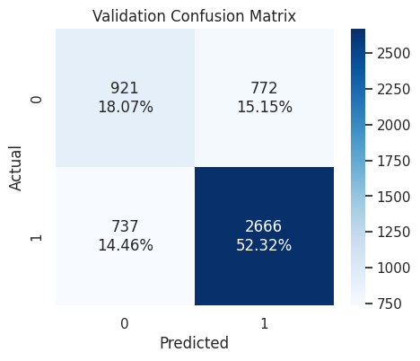

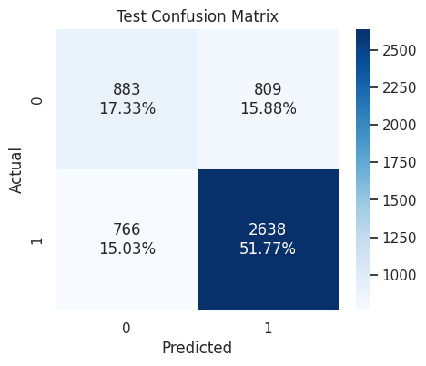

```
Model has no feature_importances_ attribute.
```

```python
# Bagging
bag_model = BaggingClassifier(random_state=1)
bag_model.fit(X_train, y_train)

# Evaluate performance
evaluate_model(bag_model)
```

## Random Forest

```
            Accuracy    Recall  Precision        F1
Dataset
Train       1.000000  1.000000   1.000000  1.000000
Validation  0.728218  0.846606   0.769498  0.806212
Test        0.721350  0.839307   0.765952  0.800953
```

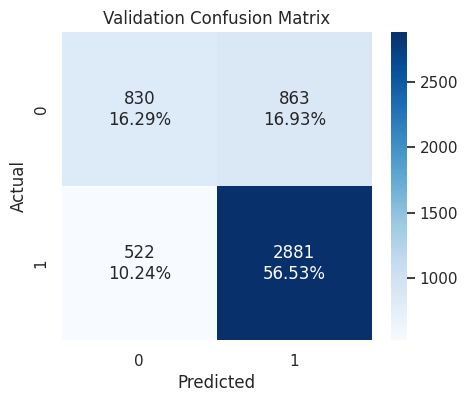

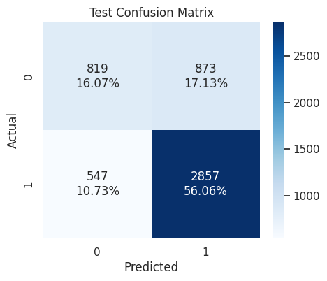

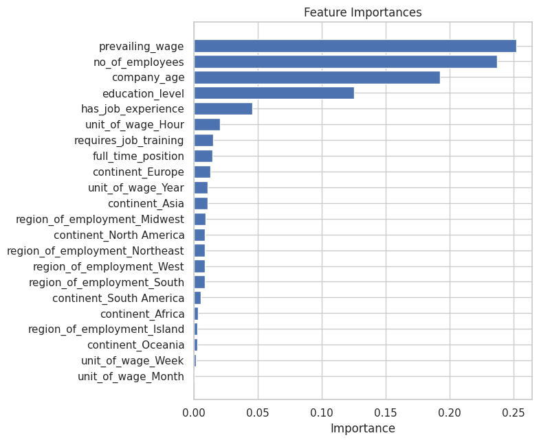

```python
# Build a Random Forest model
rf_model = RandomForestClassifier(random_state=1)
rf_model.fit(X_train, y_train)

# Evaluate performance
evaluate_model(rf_model)
```

## Decision Tree

[output not shown]

[figure not shown]

[figure not shown]

[figure not shown]

```python
# Build a Decision Tree Model
dt_model = DecisionTreeClassifier(random_state=1)
dt_model.fit(X_train, y_train)

# Evaluate performance
evaluate_model(rf_model)
```

## XGBoost

```
            Accuracy    Recall  Precision        F1
Dataset
Train       0.851060  0.934678   0.855657  0.893424
Validation  0.729199  0.859830   0.764168  0.809181
Test        0.717622  0.849882   0.757132  0.800830
```

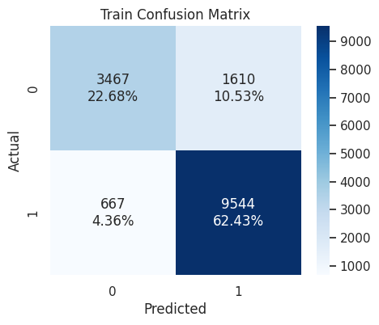

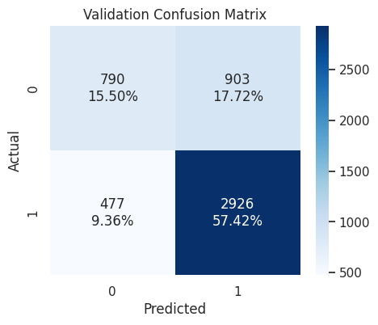

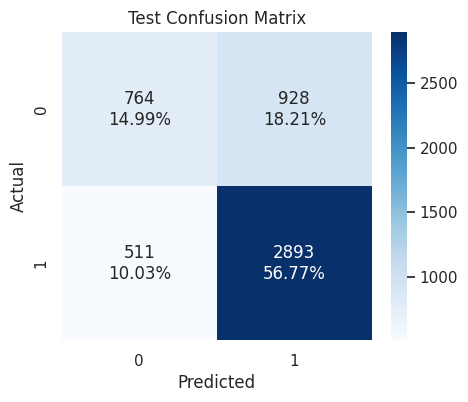

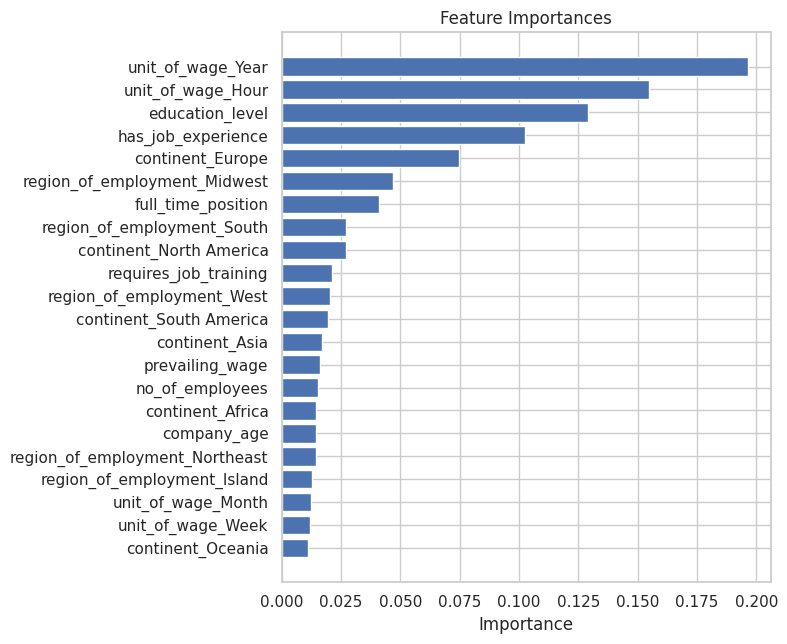

```python
# Build an XGBoost model
xgb_model = XGBClassifier(random_state=1, eval_metric='logloss')
xgb_model.fit(X_train, y_train)

# Evaluate performance
evaluate_model(xgb_model)
```

```python
base_models = {
  'Gradient Boost': gb_model,
  'AdaBoost': ada_model,
  'Bagging': bag_model,
  'Random Forest': rf_model,
  'Decision Tree': dt_model,
  'XGBoost': xgb_model,
}
compare_multiple_models(base_models)
```

```
Accuracy Comparison:
```

|  | Gradient Boost | AdaBoost | Bagging | Random Forest | Decision Tree | XGBoost |
| --- | --- | --- | --- | --- | --- | --- |
| Train | 0.759027 | 0.740123 | 0.98489 | 1.0 | 1.0 | 0.85106 |
| Validation | 0.747253 | 0.735871 | 0.703885 | 0.728218 | 0.655024 | 0.729199 |
| Test | 0.742936 | 0.729396 | 0.690934 | 0.72135 | 0.652865 | 0.717622 |

```
Recall Comparison:
```

|  | Gradient Boost | AdaBoost | Bagging | Random Forest | Decision Tree | XGBoost |
| --- | --- | --- | --- | --- | --- | --- |
| Train | 0.87866 | 0.881207 | 0.986975 | 1.0 | 1.0 | 0.934678 |
| Validation | 0.876873 | 0.885983 | 0.783426 | 0.846606 | 0.739641 | 0.85983 |
| Test | 0.873384 | 0.876322 | 0.774971 | 0.839307 | 0.737074 | 0.849882 |

```
Precision Comparison:
```

|  | Gradient Boost | AdaBoost | Bagging | Random Forest | Decision Tree | XGBoost |
| --- | --- | --- | --- | --- | --- | --- |
| Train | 0.785846 | 0.765266 | 0.990369 | 1.0 | 1.0 | 0.855657 |
| Validation | 0.774461 | 0.758872 | 0.775451 | 0.769498 | 0.742697 | 0.764168 |
| Test | 0.771807 | 0.756914 | 0.765303 | 0.765952 | 0.741649 | 0.757132 |

```
F1 Comparison:
```

|  | Gradient Boost | AdaBoost | Bagging | Random Forest | Decision Tree | XGBoost |
| --- | --- | --- | --- | --- | --- | --- |
| Train | 0.829665 | 0.819154 | 0.988669 | 1.0 | 1.0 | 0.893424 |
| Validation | 0.822492 | 0.817516 | 0.779418 | 0.806212 | 0.741166 | 0.809181 |
| Test | 0.81946 | 0.812253 | 0.770107 | 0.800953 | 0.739355 | 0.80083 |

## Base Model F₁ Comparison

**Best Model by F₁ Score: Gradient Boosting**

- **Test F₁:** 0.8195 (highest among all models)
- **Validation F₁:** 0.8225 (also the top performer)
- **Generalization Gap (Train→Test):** 0.8297 → 0.8195 (Δ ≈ –0.0102), indicating minimal over‐fitting

| Model | Train F₁ | Validation F₁ | Test F₁ | Δ (Train–Test) |
| --- | --- | --- | --- | --- |
| **Gradient Boost** | 0.8297 | 0.8225 | **0.8195** | 0.0102 |
| AdaBoost | 0.8192 | 0.8175 | 0.8123 | 0.0069 |
| XGBoost | 0.8934 | 0.8092 | 0.8008 | 0.0926 |
| Random Forest | 1.0000 | 0.8062 | 0.8010 | 0.1990 |
| Bagging | 0.9887 | 0.7794 | 0.7701 | 0.2186 |
| Decision Tree | 1.0000 | 0.7412 | 0.7394 | 0.2606 |

We will move forward with Over/Under-sampling and Hyperparameter Tuning to see if this model remains the best, and whether we can get better results.

# Oversampling

### Oversampling with SMOTE

```python
print("Before Oversampling, counts of label 'Yes': {}".format(sum(y_train == 1)))
print("Before Oversampling, counts of label 'No': {} \n".format(sum(y_train == 0)))


# SMOTE: Stands for Synthetic Minority Oversampling Technique.
# It generates synthetic samples for the minority class instead of simply
# duplicating existing samples.

sm = SMOTE(
    sampling_strategy=1,  # 1 means the minority class will be oversampled to match the number of samples in the majority class (i.e., a 1:1 balance).
    k_neighbors=5, # For each minority class sample, SMOTE picks 5 nearest neighbors and interpolates between them to create synthetic data points.
    random_state=1
)


# Synthetic Minority Over Sampling Technique
# X_train_over: The new training feature set with additional synthetic samples for the minority class.
# y_train_over: The new target labels corresponding to the oversampled dataset.

X_train_over, y_train_over = sm.fit_resample(X_train, y_train)


print("After Oversampling, counts of label 'Yes': {}".format(sum(y_train_over == 1)))
print("After Oversampling, counts of label 'No': {} \n".format(sum(y_train_over == 0)))


print("After Oversampling, the shape of train_X: {}".format(X_train_over.shape))
print("After Oversampling, the shape of train_y: {} \n".format(y_train_over.shape))
```

```
Before Oversampling, counts of label 'Yes': 10211
Before Oversampling, counts of label 'No': 5077

After Oversampling, counts of label 'Yes': 10211
After Oversampling, counts of label 'No': 10211

After Oversampling, the shape of train_X: (20422, 22)
After Oversampling, the shape of train_y: (20422,)
```

## Gradient oversampled

```
            Accuracy    Recall  Precision        F1
Dataset
Train       0.736918  0.766624   0.826872  0.795609
Validation  0.727630  0.766383   0.814745  0.789824
Test        0.715856  0.752350   0.808907  0.779604
```

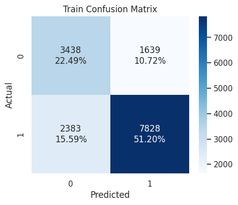

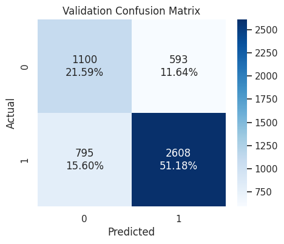

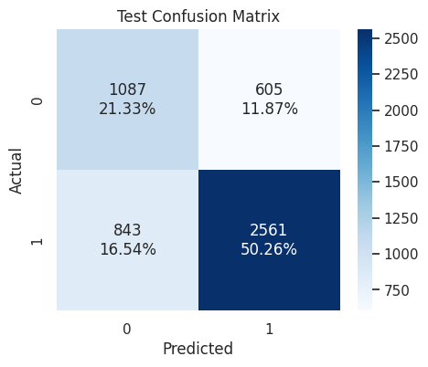

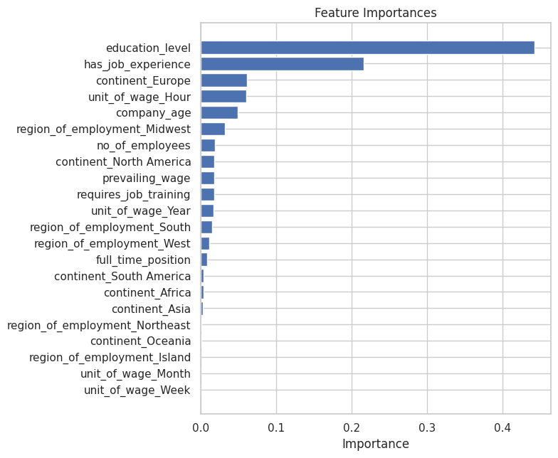

```python
# Gradient Boosting on oversampled data
gb_over = GradientBoostingClassifier(random_state=1)
gb_over.fit(X_train_over, y_train_over)

evaluate_model(gb_over)
```

## AdaBoost oversampled

```
            Accuracy    Recall  Precision        F1
Dataset
Train       0.711473  0.734012   0.815560  0.772641
Validation  0.707614  0.734058   0.810250  0.770274
Test        0.693485  0.722973   0.799026  0.759099
```

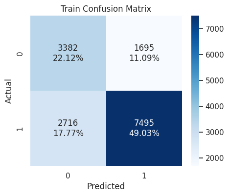

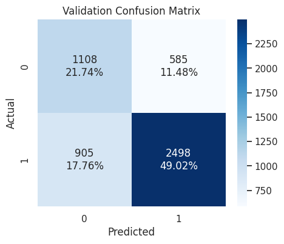

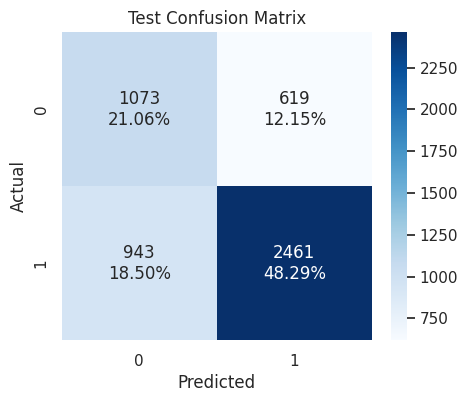

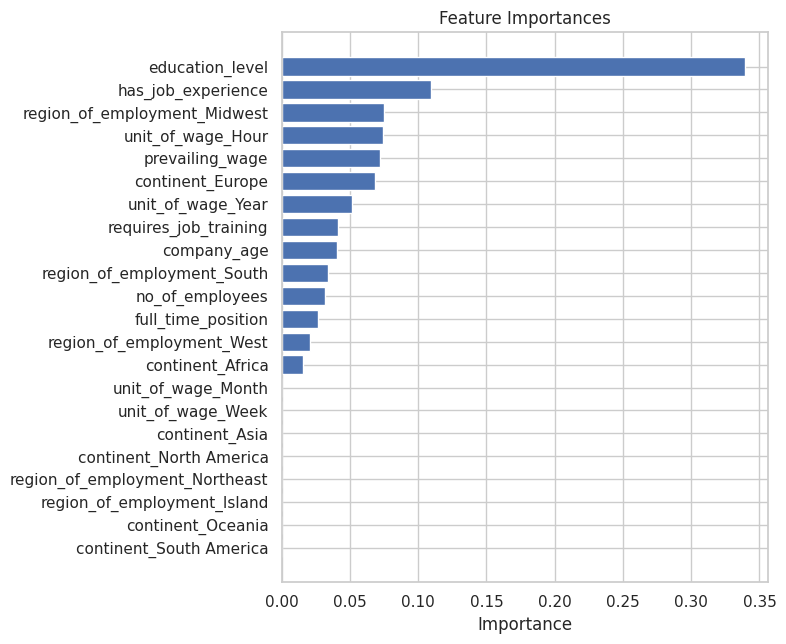

```python
# AdaBoost on oversampled data
ada_over = AdaBoostClassifier(random_state=1)
ada_over.fit(X_train_over, y_train_over)

# Evaluate performance
evaluate_model(ada_over)
```

## Bagging oversampled

```
            Accuracy    Recall  Precision        F1
Dataset
Train       1.000000  1.000000   1.000000  1.000000
Validation  0.706436  0.766383   0.788154  0.777116
Test        0.698980  0.762632   0.781457  0.771930
```

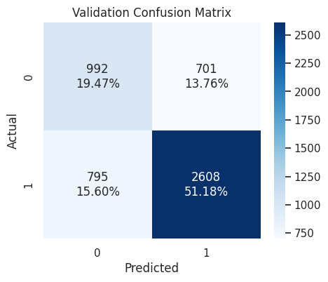

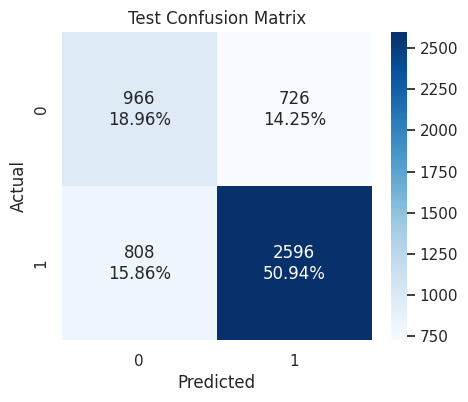

```
Model has no feature_importances_ attribute.
```

```python
# Bagging (with decision tree base) on oversampled data
bag_over = BaggingClassifier(
    estimator=DecisionTreeClassifier(random_state=1),
    n_estimators=100,
    random_state=1,
    n_jobs=-1
)
bag_over.fit(X_train_over, y_train_over)

# Evaluate performance
evaluate_model(bag_over)
```

## Random Forest oversampled

```
            Accuracy    Recall  Precision        F1
Dataset
Train       1.000000  1.000000   1.000000  1.000000
Validation  0.707614  0.774317   0.784927  0.779586
Test        0.697802  0.766157   0.778043  0.772054
```

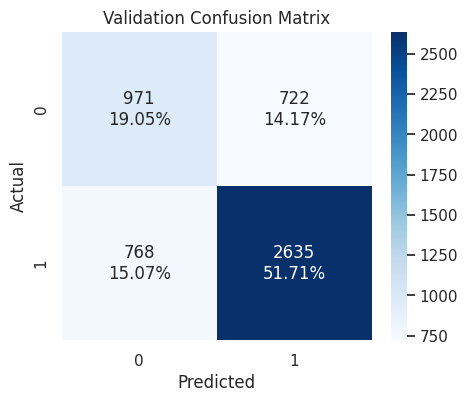

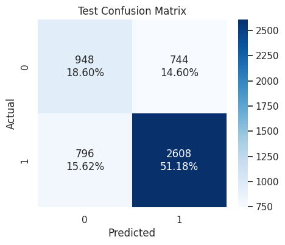

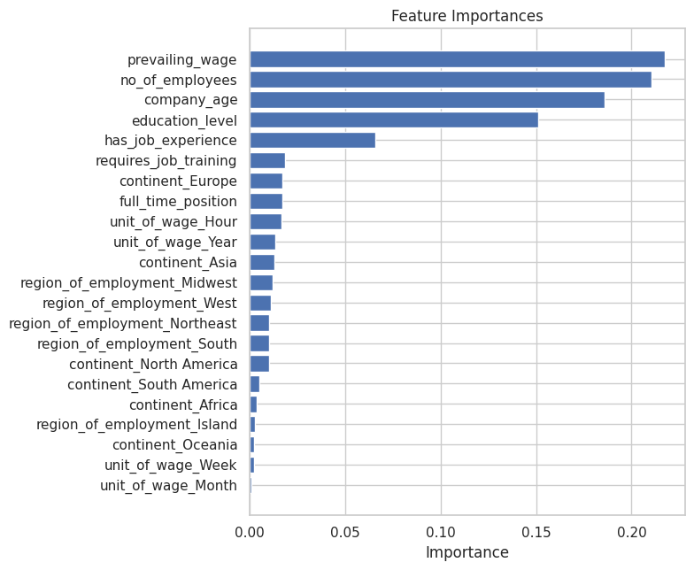

```python
# Random Forest on oversampled data
rf_over = RandomForestClassifier(random_state=1, n_jobs=-1)
rf_over.fit(X_train_over, y_train_over)

# Evaluate performance
evaluate_model(rf_over)
```

## Decision Tree oversampled

```
            Accuracy    Recall  Precision        F1
Dataset
Train       1.000000  1.000000   1.000000  1.000000
Validation  0.649137  0.705260   0.753532  0.728597
Test        0.647370  0.705053   0.751644  0.727603
```

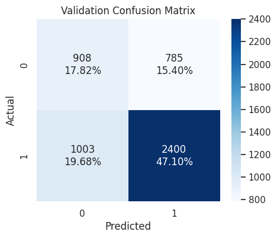

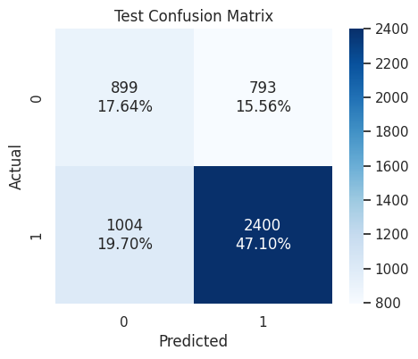

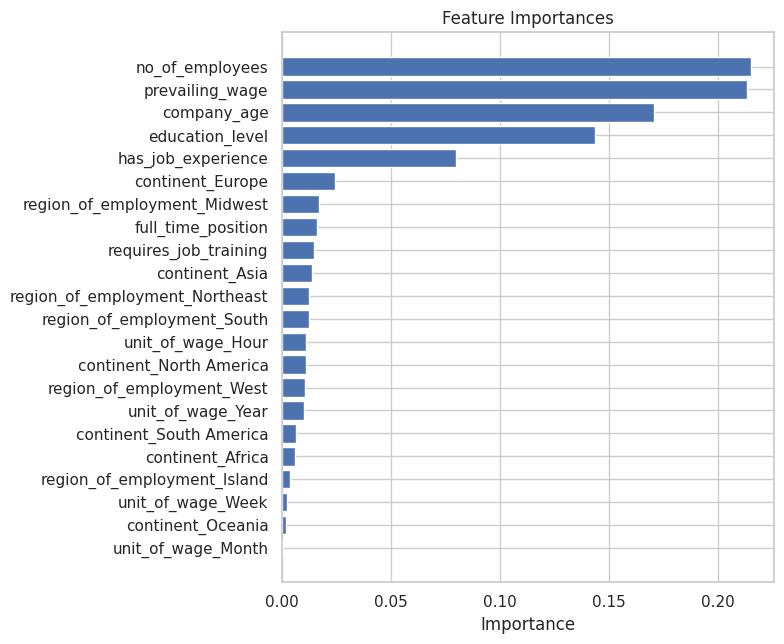

```python
# Decision Tree on oversampled data
dt_over = DecisionTreeClassifier(random_state=1)
dt_over.fit(X_train_over, y_train_over)

# Evaluate performance
evaluate_model(dt_over)
```

## XGBoost oversampled

```
            Accuracy    Recall  Precision        F1
Dataset
Train       0.826727  0.861326   0.877044  0.869114
Validation  0.719584  0.787247   0.791667  0.789450
Test        0.709380  0.780846   0.783378  0.782110
```

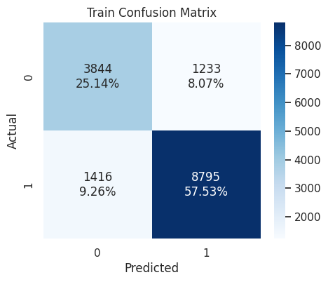

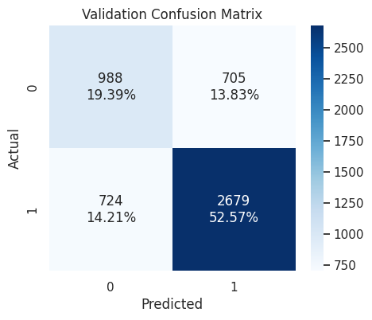

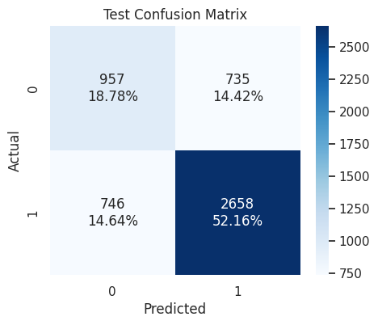

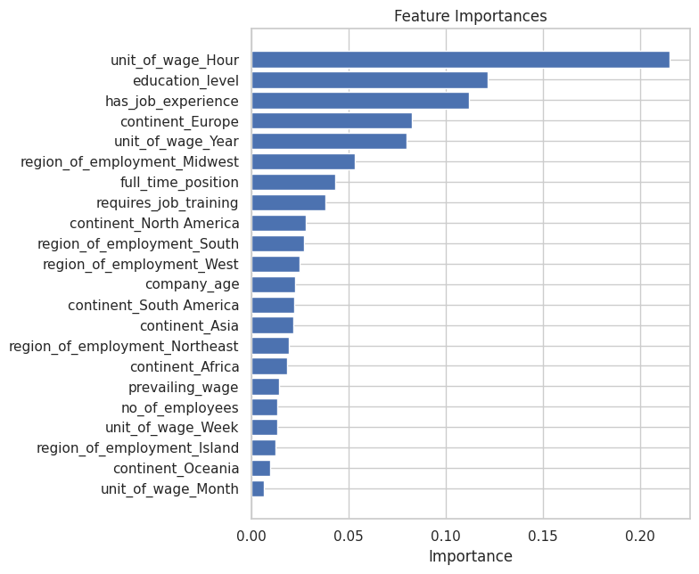

```python
# XGBoost on oversampled data
xgb_over = XGBClassifier(random_state=1, eval_metric='logloss', use_label_encoder=False)
xgb_over.fit(X_train_over, y_train_over)

# Evaluate performance
evaluate_model(xgb_over)
```

```python
os_models = {
  'GB Over': gb_over,
  'AdaOver': ada_over,
  'BagOver': bag_over,
  'RF Over': rf_over,
  'DT Over': dt_over,
  'XGB Over': xgb_over,
}
compare_multiple_models(os_models)
```

```
Accuracy Comparison:
```

|  | GB Over | AdaOver | BagOver | RF Over | DT Over | XGB Over |
| --- | --- | --- | --- | --- | --- | --- |
| Train | 0.736918 | 0.711473 | 1.0 | 1.0 | 1.0 | 0.826727 |
| Validation | 0.72763 | 0.707614 | 0.706436 | 0.707614 | 0.649137 | 0.719584 |
| Test | 0.715856 | 0.693485 | 0.69898 | 0.697802 | 0.64737 | 0.70938 |

```
Recall Comparison:
```

|  | GB Over | AdaOver | BagOver | RF Over | DT Over | XGB Over |
| --- | --- | --- | --- | --- | --- | --- |
| Train | 0.766624 | 0.734012 | 1.0 | 1.0 | 1.0 | 0.861326 |
| Validation | 0.766383 | 0.734058 | 0.766383 | 0.774317 | 0.70526 | 0.787247 |
| Test | 0.75235 | 0.722973 | 0.762632 | 0.766157 | 0.705053 | 0.780846 |

```
Precision Comparison:
```

|  | GB Over | AdaOver | BagOver | RF Over | DT Over | XGB Over |
| --- | --- | --- | --- | --- | --- | --- |
| Train | 0.826872 | 0.81556 | 1.0 | 1.0 | 1.0 | 0.877044 |
| Validation | 0.814745 | 0.81025 | 0.788154 | 0.784927 | 0.753532 | 0.791667 |
| Test | 0.808907 | 0.799026 | 0.781457 | 0.778043 | 0.751644 | 0.783378 |

```
F1 Comparison:
```

|  | GB Over | AdaOver | BagOver | RF Over | DT Over | XGB Over |
| --- | --- | --- | --- | --- | --- | --- |
| Train | 0.795609 | 0.772641 | 1.0 | 1.0 | 1.0 | 0.869114 |
| Validation | 0.789824 | 0.770274 | 0.777116 | 0.779586 | 0.728597 | 0.78945 |
| Test | 0.779604 | 0.759099 | 0.77193 | 0.772054 | 0.727603 | 0.78211 |

## Test-Set F₁: Base vs. Oversampled Models

| Model | Base Test F₁ | Oversampled Test F₁ | Δ F₁ (Over–Base) |
| --- | --- | --- | --- |
| Gradient Boosting | 0.8195 | 0.7796 | –0.0399 |
| AdaBoost | 0.8123 | 0.7591 | –0.0532 |
| XGBoost | 0.8008 | 0.7821 | –0.0187 |
| Random Forest | 0.8010 | 0.7721 | –0.0289 |
| Bagging | 0.7701 | 0.7719 | +0.0018 |
| Decision Tree | 0.7394 | 0.7276 | –0.0118 |

**Key Observations:**

- **Most boosting models (GB, Ada, XGB)** see a **notable drop** in F₁ (≈ 0.02–0.05) after naïve oversampling, suggesting that synthetic positives introduce noise without further hyperparameter adjustment.
- **Random Forest** also declines (≈ –0.03), while **Decision Tree** drops only slightly (≈ –0.01).
- **Bagging** is the **only model to improve** marginally (+0.002), indicating its high-variance ensemble can better absorb oversampled data.
- Overall, simple oversampling **degrades F₁** for most learners.

# Undersampling

```python
# fit random under sampler on the train data
rus = RandomUnderSampler(random_state=1, sampling_strategy = 1)
X_train_un, y_train_un = rus.fit_resample(X_train, y_train)

print("Before Under Sampling, count of label '1': {}".format(sum(y_train == 1)))
print("Before Under Sampling, count of label '0': {} \n".format(sum(y_train == 0)))

print("After Under Sampling, count of label '1': {}".format(sum(y_train_un == 1)))
print("After Under Sampling, count of label '0': {} \n".format(sum(y_train_un == 0)))

print("After Under Sampling, the shape of X_train: {}".format(X_train_un.shape))
print("After Under Sampling, the shape of X_train: {} \n".format(y_train_un.shape))
```

```
Before Under Sampling, count of label '1': 10211
Before Under Sampling, count of label '0': 5077

After Under Sampling, count of label '1': 5077
After Under Sampling, count of label '0': 5077

After Under Sampling, the shape of X_train: (10154, 22)
After Under Sampling, the shape of X_train: (10154,)
```

## Gradient Boosting Undersampled

```
            Accuracy    Recall  Precision        F1
Dataset
Train       0.729199  0.736852   0.838142  0.784240
Validation  0.712716  0.729650   0.820284  0.772317
Test        0.700353  0.719448   0.810659  0.762335
```

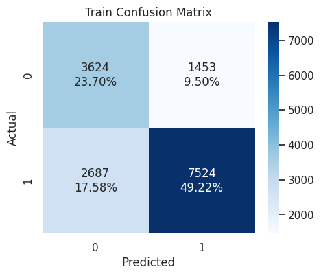

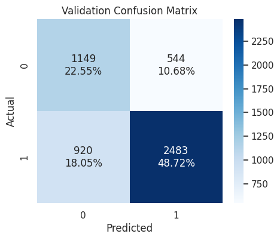

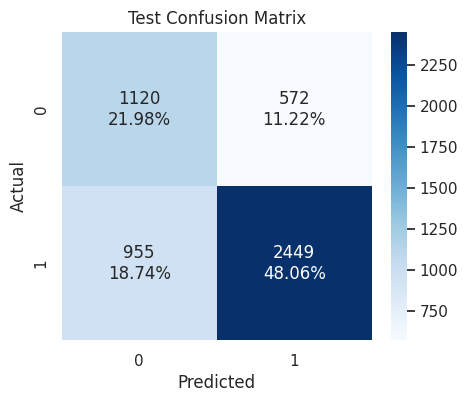

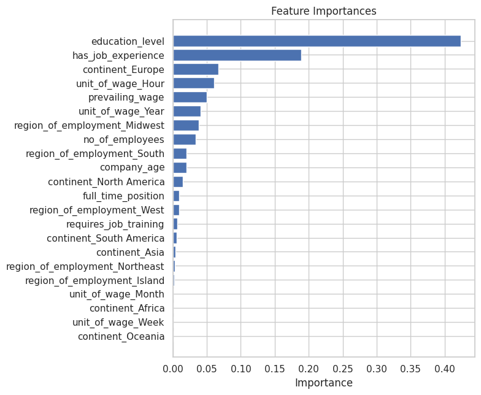

```python
# Gradient Boost on undersampled data
gb_under = GradientBoostingClassifier(random_state=1)
gb_under.fit(X_train_un, y_train_un)

# Evaluate performance
evaluate_model(gb_under)
```

## AdaBoost Undersampled

```
            Accuracy    Recall  Precision        F1
Dataset
Train       0.707287  0.729801   0.812827  0.769080
Validation  0.709184  0.736703   0.810540  0.771860
Test        0.690542  0.722092   0.795727  0.757123
```

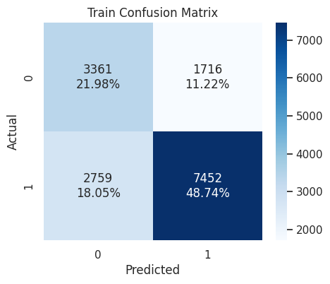

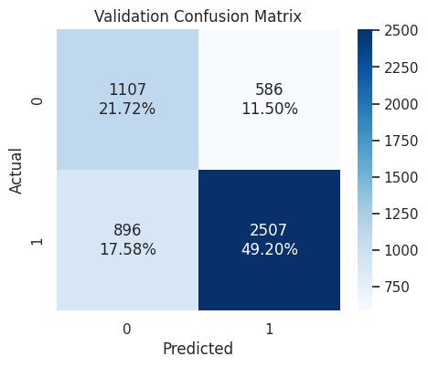

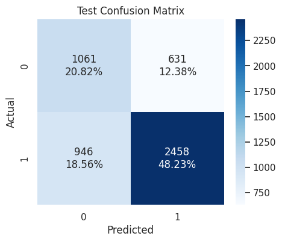

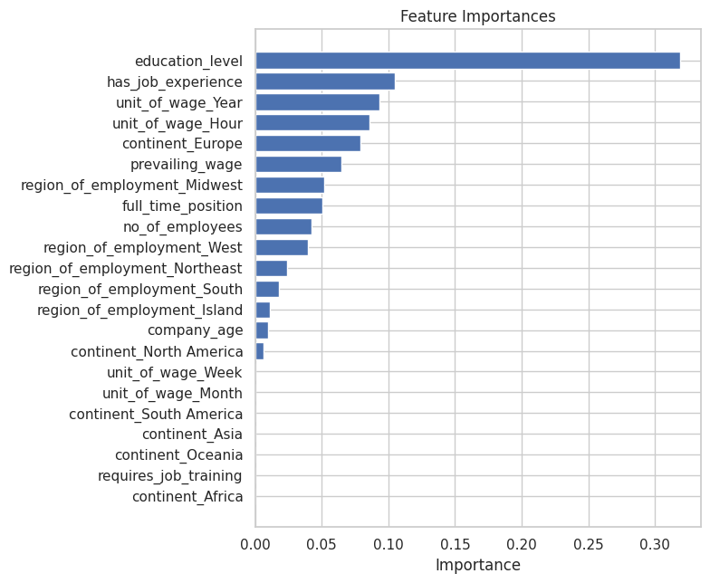

```python
# AdaBoost on undersampled data
ada_under = AdaBoostClassifier(random_state=1)
ada_under.fit(X_train_un, y_train_un)

# Evaluate performance
evaluate_model(ada_under)
```

## Bagging Undersampled

```
            Accuracy    Recall  Precision        F1
Dataset
Train       0.890437  0.835961   1.000000  0.910652
Validation  0.687009  0.691449   0.811939  0.746866
Test        0.678571  0.679201   0.808957  0.738422
```

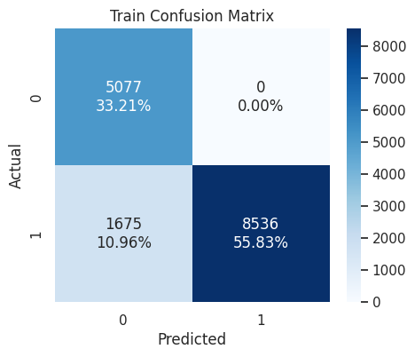

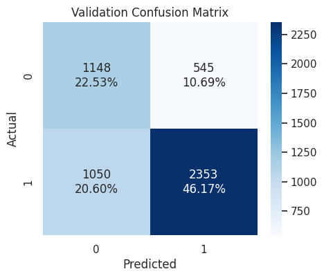

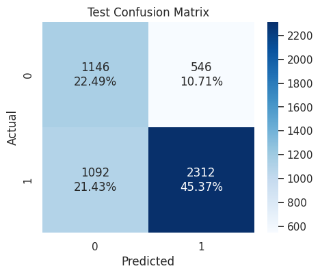

```
Model has no feature_importances_ attribute.
```

```python
# Bagging Classifier on undersampled data
bag_under = BaggingClassifier(
    estimator=DecisionTreeClassifier(random_state=1),
    n_estimators=100,
    random_state=1,
    n_jobs=-1
)
bag_under.fit(X_train_un, y_train_un)

# Evaluate performance
evaluate_model(bag_under)
```

## Random Forest Undersampled

```
            Accuracy    Recall  Precision        F1
Dataset
Train       0.891745  0.837920   1.000000  0.911813
Validation  0.687402  0.692036   0.812069  0.747263
Test        0.679749  0.684489   0.806787  0.740623
```

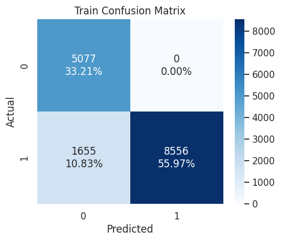

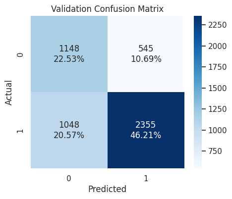

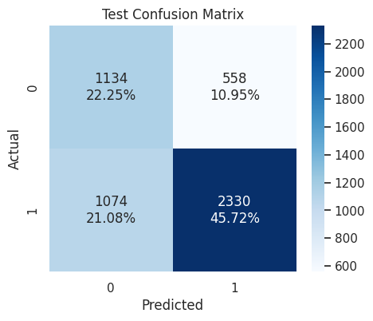

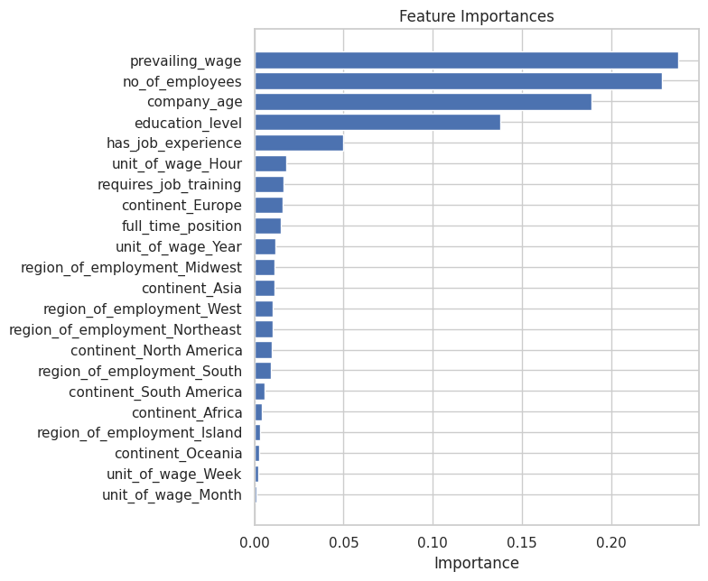

```python
# Random Forest on undersampled data
rf_under = RandomForestClassifier(random_state=1, n_jobs=-1)
rf_under.fit(X_train_un, y_train_un)

# Evaluate performance
evaluate_model(rf_under)
```

## Decision Tree Undersampled

```
            Accuracy    Recall  Precision        F1
Dataset
Train       0.877943  0.817256   1.000000  0.899440
Validation  0.623626  0.633559   0.762646  0.692135
Test        0.621664  0.622797   0.767004  0.687419
```

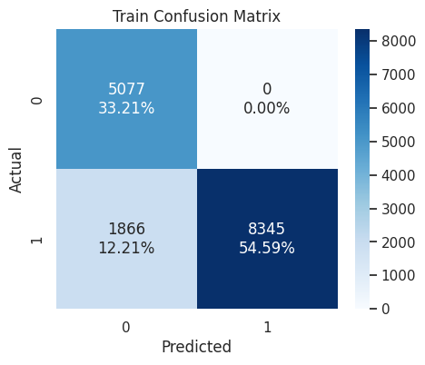

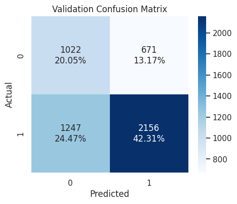

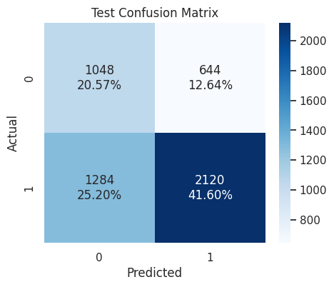

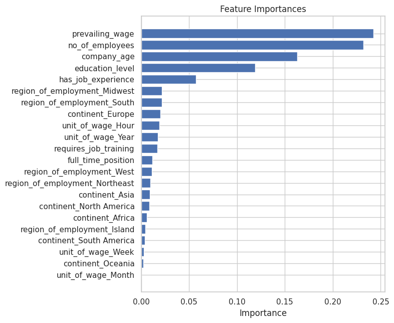

```python
# Decision Tree on undersampled data
dt_under = DecisionTreeClassifier(random_state=1)
dt_under.fit(X_train_un, y_train_un)

# Evaluate performance
evaluate_model(dt_under)
```

## XGBoost Undersampled

```
            Accuracy    Recall  Precision        F1
Dataset
Train       0.808019  0.780629   0.919802  0.844520
Validation  0.685832  0.688804   0.812197  0.745429
Test        0.678375  0.685958   0.803787  0.740212
```

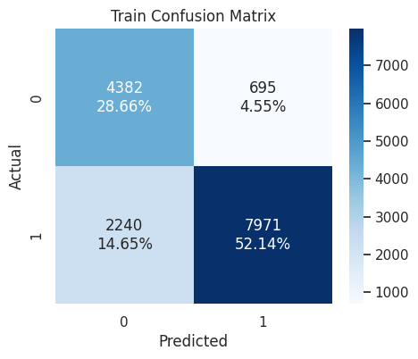

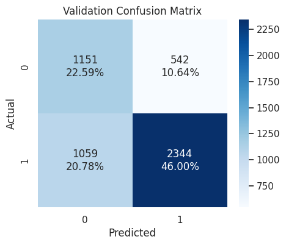

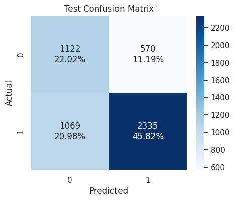

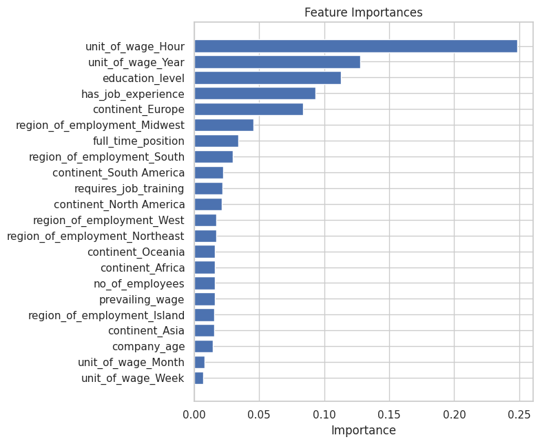

```python
# XGBoost on undersampled data
xgb_under = XGBClassifier(random_state=1, eval_metric='logloss', use_label_encoder=False)
xgb_under.fit(X_train_un, y_train_un)

# Evaluate performance
evaluate_model(xgb_under)
```

```python
us_models = {
  'GB Under': gb_under,
  'AdaUnder': ada_under,
  'BagUnder': bag_under,
  'RF Under': rf_under,
  'DT Under': dt_under,
  'XGB Under': xgb_under,
}
compare_multiple_models(us_models)
```

```
Accuracy Comparison:
```

|  | GB Under | AdaUnder | BagUnder | RF Under | DT Under | XGB Under |
| --- | --- | --- | --- | --- | --- | --- |
| Train | 0.729199 | 0.707287 | 0.890437 | 0.891745 | 0.877943 | 0.808019 |
| Validation | 0.712716 | 0.709184 | 0.687009 | 0.687402 | 0.623626 | 0.685832 |
| Test | 0.700353 | 0.690542 | 0.678571 | 0.679749 | 0.621664 | 0.678375 |

```
Recall Comparison:
```

|  | GB Under | AdaUnder | BagUnder | RF Under | DT Under | XGB Under |
| --- | --- | --- | --- | --- | --- | --- |
| Train | 0.736852 | 0.729801 | 0.835961 | 0.83792 | 0.817256 | 0.780629 |
| Validation | 0.72965 | 0.736703 | 0.691449 | 0.692036 | 0.633559 | 0.688804 |
| Test | 0.719448 | 0.722092 | 0.679201 | 0.684489 | 0.622797 | 0.685958 |

```
Precision Comparison:
```

|  | GB Under | AdaUnder | BagUnder | RF Under | DT Under | XGB Under |
| --- | --- | --- | --- | --- | --- | --- |
| Train | 0.838142 | 0.812827 | 1.0 | 1.0 | 1.0 | 0.919802 |
| Validation | 0.820284 | 0.81054 | 0.811939 | 0.812069 | 0.762646 | 0.812197 |
| Test | 0.810659 | 0.795727 | 0.808957 | 0.806787 | 0.767004 | 0.803787 |

```
F1 Comparison:
```

|  | GB Under | AdaUnder | BagUnder | RF Under | DT Under | XGB Under |
| --- | --- | --- | --- | --- | --- | --- |
| Train | 0.78424 | 0.76908 | 0.910652 | 0.911813 | 0.89944 | 0.84452 |
| Validation | 0.772317 | 0.77186 | 0.746866 | 0.747263 | 0.692135 | 0.745429 |
| Test | 0.762335 | 0.757123 | 0.738422 | 0.740623 | 0.687419 | 0.740212 |

## Undersampled vs. Base Model F₁ Comparison

| Model | Base Test F₁ | Undersampled Test F₁ | Δ F₁ (Under – Base) |
| --- | --- | --- | --- |
| Gradient Boosting | 0.8195 | 0.7623 | –0.0572 |
| AdaBoost | 0.8123 | 0.7571 | –0.0552 |
| Bagging | 0.7701 | 0.7384 | –0.0317 |
| Random Forest | 0.8010 | 0.7406 | –0.0604 |
| Decision Tree | 0.7394 | 0.6874 | –0.0520 |
| XGBoost | 0.8008 | 0.7402 | –0.0606 |

- **Undersampling** hurts F₁ across the board relative to the base (no sampling) models, with drops of ~0.03–0.07.
- **Bagging** is the most robust to undersampling (only –0.0317 F₁), while **XGBoost** (–0.0606) and **Random Forest** (–0.0604) suffer the largest drops.
- **Gradient Boosting** and **AdaBoost** each drop about –0.055, indicating that their learners also need re‐tuning when the class distribution changes.

**Future Considerations**

1. **Avoid naïve undersampling** with default settings—this generally degrades F₁ performance.
2. **Consider class‐weighting** (e.g. `class_weight='balanced'` or `scale_pos_weight` in XGBoost) instead of outright sampling to correct imbalance more gently.

**Insights & Next Steps**  
Based on the results thus far, we should use the base boosting models rather than under/over-sampling, and explore hyperparameter tuning on the most successful: gradient boosting, adaboosting, and xgboosting.

# **HyperParameter Tuning**

## **Note**

1. Sample parameter grids have been provided to do necessary hyperparameter tuning. These sample grids are expected to provide a balance between model performance improvement and execution time. One can extend/reduce the parameter grid based on execution time and system configuration.
- Please note that if the parameter grid is extended to improve the model performance further, the execution time will increase
2. The models chosen in this notebook are based on test runs. One can update the best models as obtained upon code execution and tune them for best performance.
- For Gradient Boosting:

```
param_grid = {
    "init": [AdaBoostClassifier(random_state=1),DecisionTreeClassifier(random_state=1)],
    "n_estimators": np.arange(50,110,25),
    "learning_rate": [0.01,0.1,0.05],
    "subsample":[0.7,0.9],
    "max_features":[0.5,0.7,1],
}
```

- For Adaboost:

```
param_grid = {
    "n_estimators": np.arange(50,110,25),
    "learning_rate": [0.01,0.1,0.05],
    "base_estimator": [
        DecisionTreeClassifier(max_depth=2, random_state=1),
        DecisionTreeClassifier(max_depth=3, random_state=1),
    ],
}
```

- For Bagging Classifier:

```
param_grid = {
    'max_samples': [0.8,0.9,1],
    'max_features': [0.7,0.8,0.9],
    'n_estimators' : [30,50,70],
}
```

- For Random Forest:

```
param_grid = {
    "n_estimators": [50,110,25],
    "min_samples_leaf": np.arange(1, 4),
    "max_features": [np.arange(0.3, 0.6, 0.1),'sqrt'],
    "max_samples": np.arange(0.4, 0.7, 0.1)
}
```

- For Decision Trees:

```
param_grid = {
    'max_depth': np.arange(2,6),
    'min_samples_leaf': [1, 4, 7],
    'max_leaf_nodes' : [10, 15],
    'min_impurity_decrease': [0.0001,0.001]
}
```

- For XGBoost:

```
param_grid={'n_estimators':np.arange(50,110,25),
            'scale_pos_weight':[1,2,5],
            'learning_rate':[0.01,0.1,0.05],
            'gamma':[1,3],
            'subsample':[0.7,0.9]
}
```

My note: I chose to use RandomizedSearchCV as it is both faster and gives better results (in my experience) compared with GridSearchCV. Additionally, I chose to tune the below models based upon which ones either performed well in my earlier trials or which I thought would perform well when tuned.

## Gradient Boost and Tuning

```
Best Parameters:
 {'subsample': 0.9, 'n_estimators': np.int64(75), 'max_features': 0.7, 'learning_rate': 0.05, 'init': AdaBoostClassifier(random_state=1)}

Tuned model performance:
            Accuracy    Recall  Precision        F1
Dataset
Train       0.754121  0.878269   0.780913  0.826734
Validation  0.747057  0.881281   0.772142  0.823110
Test        0.738422  0.873384   0.767226  0.816870
```

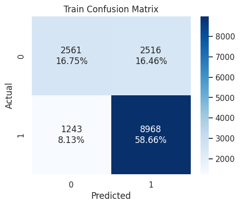

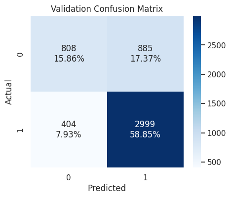

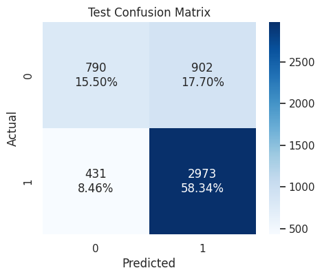

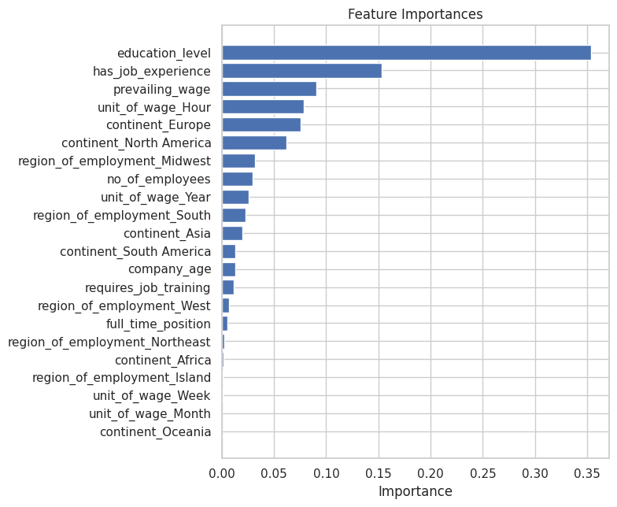

```python
param_grid = {
    "init": [AdaBoostClassifier(random_state=1),DecisionTreeClassifier(random_state=1)],
    "n_estimators": np.arange(50,110,25),
    "learning_rate": [0.01,0.1,0.05],
    "subsample":[0.7,0.9],
    "max_features":[0.5,0.7,1],
}

# initialize GradientBoostingClassifier with early stopping
gb_early = GradientBoostingClassifier(
    random_state=1,
    validation_fraction=0.1,
    n_iter_no_change=10,
    tol=1e-4
)

# set up a randomized search with a modest number of iterations
search_gb = RandomizedSearchCV(
    estimator=gb_early,
    param_distributions=param_grid,
    n_iter=10,               # fewer iterations for speed
    scoring='roc_auc',
    cv=3,                    # 3-fold for quicker runs
    random_state=42,
    n_jobs=-1
)

# fit on preprocessed training data
search_gb.fit(X_train, y_train)

# extract best model
best_gb = search_gb.best_estimator_

# evaluate performance
print("\nBest Parameters:\n", search_gb.best_params_)
print("\nTuned model performance:")
evaluate_model(best_gb)
```